# Convergence and Posterior Distribution

### Summary of posterior distribution

We already saw the `samplesSummary` function. Let’s see what else we can do with MCMC posterior samples.

```r
round(samplesSummary(samples), 2)
```

```
##            Mean Median St.Dev. 95%CI_low 95%CI_upp
## a[1]     595.16 583.10  301.80     53.02   1158.81
## a[2]       3.40   2.66    2.60      0.89     11.56
## b[1]      67.81  66.90   36.28      5.39    150.38
## b[2]       1.06   0.86    0.76      0.35      3.48
## p[1, 1]    0.90   0.90    0.03      0.84      0.95
## p[2, 1]    0.94   0.96    0.06      0.78      1.00
## p[1, 2]    0.90   0.90    0.03      0.84      0.95
## p[2, 2]    0.94   0.96    0.07      0.77      1.00
## p[1, 3]    0.90   0.90    0.03      0.84      0.95
## p[2, 3]    0.93   0.95    0.07      0.75      1.00
## p[1, 4]    0.90   0.90    0.03      0.84      0.95
## p[2, 4]    0.93   0.95    0.07      0.73      1.00
## p[1, 5]    0.90   0.90    0.03      0.84      0.95
## p[2, 5]    0.87   0.89    0.08      0.67      0.99
## p[1, 6]    0.90   0.90    0.03      0.84      0.95
## p[2, 6]    0.86   0.88    0.09      0.64      0.99
## p[1, 7]    0.90   0.90    0.03      0.84      0.95
## p[2, 7]    0.86   0.88    0.09      0.64      0.99
## p[1, 8]    0.90   0.90    0.03      0.84      0.94
## p[2, 8]    0.85   0.87    0.10      0.62      0.98
## p[1, 9]    0.90   0.90    0.03      0.84      0.94
## p[2, 9]    0.85   0.86    0.10      0.62      0.98
## p[1, 10]   0.90   0.90    0.03      0.84      0.94
## p[2, 10]   0.78   0.80    0.13      0.47      0.97
## p[1, 11]   0.90   0.90    0.03      0.84      0.94
## p[2, 11]   0.77   0.79    0.11      0.51      0.95
## p[1, 12]   0.89   0.90    0.03      0.83      0.94
## p[2, 12]   0.64   0.65    0.14      0.33      0.88
## p[1, 13]   0.90   0.90    0.03      0.83      0.94
## p[2, 13]   0.57   0.58    0.13      0.30      0.81
## p[1, 14]   0.89   0.90    0.03      0.83      0.94
## p[2, 14]   0.60   0.61    0.16      0.27      0.87
## p[1, 15]   0.89   0.89    0.03      0.83      0.94
## p[2, 15]   0.43   0.43    0.14      0.16      0.71
## p[1, 16]   0.89   0.89    0.03      0.83      0.94
## p[2, 16]   0.27   0.25    0.16      0.02      0.62
```

### Effective sample size (ESS)

When looking at the MCMC traceplot for one variable, we see that samples are not sequentially independent.

That is the nature of MCMC sampling.

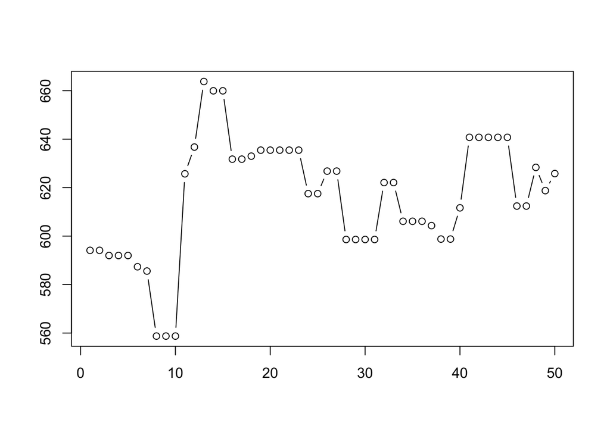

```r
plot(samples[2051:2100, 'a[1]'], type = 'b', xlab = '', ylab = '')
```

In this case we see both autocorrelation and Metropolis-Hastings rejections, which have occurred when the state does not change. This does not happen in JAGS, because it does not use Metropolis-Hastings.

*Effective sample size (ESS)* is the equivalent number of independent samples in an MCMC chain for one parameter.

### What does “equivalent number of independent samples” mean?

If the $m$ posterior samples of $p_i$ were drawn independently, we could say:

$\text{var}(\bar{p_i}) = \text{var}( \frac{1}{m} \sum_{i = 1}^m p_i )= \frac{\text{var}(p_i)}{m}$

Instead, we have

$\text{var}(\bar{p_i}) = \frac{\text{var}(p_i)}{\text{ESS}}$

where ESS is the *Effective Sample Size*.

### Calculate ESS: `effectiveSize`

The `coda` R package provides a function for calculating the ESS, called `effectiveSize`.

Out of our 10,000 samples, let’s see the equivlent number of *independent* posterior samples:

```r
library(coda)
```

```r
ESS <- coda::effectiveSize(samples)
```

```r
round(ESS)
```

```
##     a[1]     a[2]     b[1]     b[2]  p[1, 1]  p[2, 1]  p[1, 2]  p[2, 2]
##        6       97        6       93       56      873       74      999
##  p[1, 3]  p[2, 3]  p[1, 4]  p[2, 4]  p[1, 5]  p[2, 5]  p[1, 6]  p[2, 6]
##       64     1060       57     1071       57     4648       61     3977
##  p[1, 7]  p[2, 7]  p[1, 8]  p[2, 8]  p[1, 9]  p[2, 9] p[1, 10] p[2, 10]
##       62     3821       65     6825       70     7581       75     8044
## p[1, 11] p[2, 11] p[1, 12] p[2, 12] p[1, 13] p[2, 13] p[1, 14] p[2, 14]
##       66     8607       65     4290       63     2062       68     2977
## p[1, 15] p[2, 15] p[1, 16] p[2, 16]
##       67      841       62      302
```

We can see that the effective sample size is considerably smaller than the number of samples!

### Measuring MCMC performance: MCMC efficiency

We define *MCMC efficiency* as

$\text{Efficiency} = \frac{\text{ESS}}{\text{computation time}}$

This is the number of effectively independent samples generated per time. The ESS is different for every parameter, but computation time is the same for every parameter: the total time.

We do not count setup steps like model building and compilation as part of computation time. Even though these take time, we are more interested in the final MCMC performance.

We want a single number to measure the performance of an MCMC. Often there are many fast-mixing parameters and one or a few slow-mixing ones. We need all parameters to be mixed well to rely on results.

Therefore our single measure of efficiency is:

**Net MCMC efficiency = Minimum MCMC efficiency over all parameters**

It may be tempting to think mean (across parameters) of MCMC efficiency is a good measure of overall performance. If you rely on mean efficiency, you could end up like the statistician who drowned in a river with an average depth of three feet.

That is, if some parameters are mixing very well and others very poorly, you should not feel the results are acceptable.

### Visual inspection of posterior distributions

We’ll use the `basicMCMCplots` function to visually inspect the posterior. It provides several functions for looking at one or more MCMC chains.

First, let’s run the `litters` MCMC again, to generate 3 chains of samples:

```r
samplesList <- runMCMC(cLittersMCMC,
                       niter = 15000,
                       nburnin = 5000,
                       nchains = 3)

samples <- samplesList[[1]]
```

### `samplesPlot` function for looking at one chain

We’ll look at the first chain only, first.

`samplesPlot` let’s you visually inspect one chain.

We’ll only look at the `a` and `b` variables.

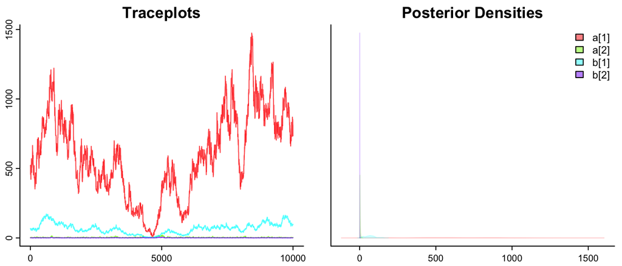

```r
library(basicMCMCplots)

basicMCMCplots::samplesPlot(samples, var = c("a", "b"))
```

Since these are on vastly difference scales, we can use the `scale = TRUE` argument, to normalize them. This will let us look at the actual mixing.

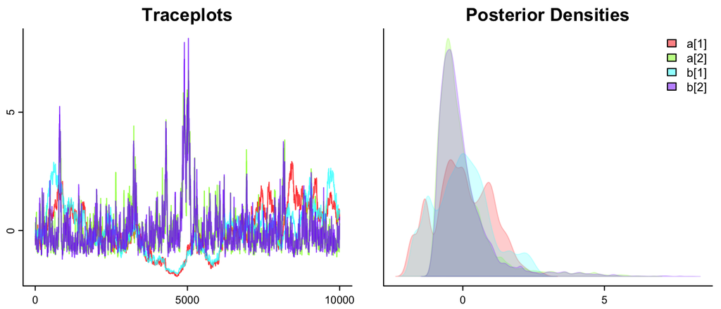

```r
basicMCMCplots::samplesPlot(samples,
                            var = c("a", "b"),
                            scale = TRUE)
```

The mixing for `a[1]` and `b[1]` doesn’t look very good. We’ll see if we can improve that, later.

Notice the arguments `densityplot = FALSE`, and `burnin`:

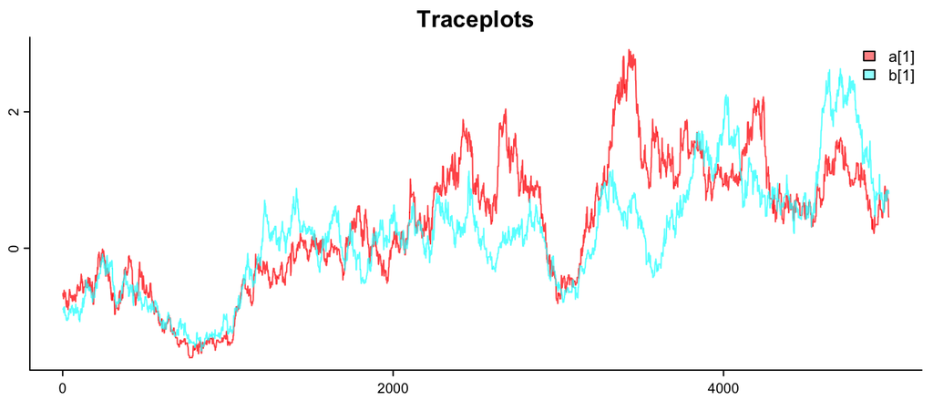

```r
basicMCMCplots::samplesPlot(samples,
                            var = c("a[1]", "b[1]"),
                            scale = TRUE,
                            densityplot = FALSE,
                            burnin = 5000)
```

**Question**: What seems to be happening with `a[1]` and `b[1]` ??

Mixing is not the best. We’ll explore different sampling strategies that fix the problems later in the workshop.

### `chainsPlot` and `chainsSummary` for inspecting multiple chains

The `chainsPlot` function of the `basicMCMCplots` package is analogous to `samplesPlot`, but lets you inspect multiple chains.

Here, we’ll use the `samplesList` object, which contains 3 MCMC chains.

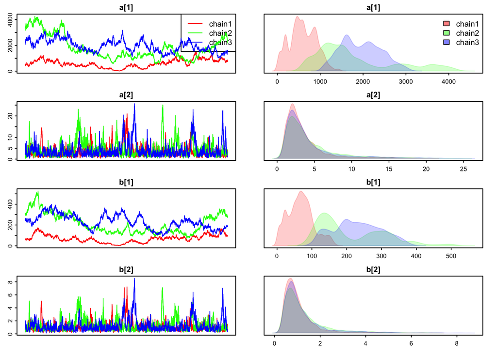

```r
basicMCMCplots::chainsPlot(samplesList,
                           var = c("a", "b"))
```

The `chainsPlot` function provides many arguments also, to control variables, burnin, number of columns, the legend, and saving the plot to a file. See `help(chainsPlot)` for more information.

Finally, `chainsSummary` will help us quickly compare the posteriors from multiple chains.

This can be very useful, to visually check if the chains agree with each other.

The circles represent posterior medians, and the vertical lines show 95% Bayesian Credible Intervals (BCIs).

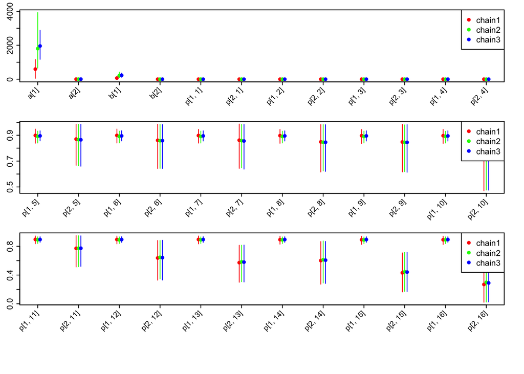

```r
basicMCMCplots::chainsSummary(samplesList)
```

These generally look good, except the `a[1]` parameter looks troublsome. Perhaps the `b[1]` parameter, too.

### Assessing MCMC convergence from multiple chains

We’ll use the `coda` package again to assess convergence of our MCMC.

We’ll use the commonly used Gelman-Rubin potential scale reduction factor diagnostic, which requires multiple chains.

However, the `gelman.diag` from the `coda` package requires the MCMC samples to be `coda.mcmc` objects. So, NIMBLE’s `runMCMC` function provides an option for this:

```r
samplesCodaList <- runMCMC(cLittersMCMC,
                           niter = 15000,
                           nburnin = 5000,
                           nchains = 3,
                           samplesAsCodaMCMC = TRUE)
```

```r
gelman.diag(samplesCodaList)
```

```
## Potential scale reduction factors:
##
##          Point est. Upper C.I.
## a[1]           1.35       1.92
## a[2]           1.11       1.26
## b[1]           1.37       2.02
## b[2]           1.10       1.25
## p[1, 1]        1.06       1.17
## p[2, 1]        1.01       1.02
## p[1, 2]        1.06       1.17
## p[2, 2]        1.00       1.01
## p[1, 3]        1.06       1.17
## p[2, 3]        1.00       1.02
## p[1, 4]        1.06       1.17
## p[2, 4]        1.01       1.02
## p[1, 5]        1.06       1.17
## p[2, 5]        1.00       1.00
## p[1, 6]        1.06       1.17
## p[2, 6]        1.00       1.00
## p[1, 7]        1.06       1.17
## p[2, 7]        1.00       1.01
## p[1, 8]        1.06       1.18
## p[2, 8]        1.00       1.00
## p[1, 9]        1.06       1.17
## p[2, 9]        1.00       1.00
## p[1, 10]       1.06       1.18
## p[2, 10]       1.00       1.00
## p[1, 11]       1.06       1.18
## p[2, 11]       1.00       1.00
## p[1, 12]       1.06       1.16
## p[2, 12]       1.00       1.01
## p[1, 13]       1.06       1.17
## p[2, 13]       1.00       1.01
## p[1, 14]       1.06       1.16
## p[2, 14]       1.00       1.01
## p[1, 15]       1.06       1.16
## p[2, 15]       1.01       1.04
## p[1, 16]       1.06       1.16
## p[2, 16]       1.02       1.05
##
## Multivariate psrf
##
## 1.26
```

For “convergence”, we want these values (“scale reduction factors”) to be very close to 1. They’ll never be less than 1, but should be as close to 1 as possible.

This is not very good. The mixing of the `a[1]` and `b[1]` has not converged.

### Other MCMC tools in NIMBLE

- WAIC for model comparison
- Cross-validation